# Машинное обучение

## Практическое задание №1

Проанализируйте данные о мировом рынке вакансий в сфере ИИ в 2025 году.

Файл `ai_job_dataset_upd.csv` содержит следующие признаки:

| Variable name | Variable description |:-------------------:|:------------------:| | job_id | Unique identifier for each job posting | | job_title | Standardized job title | | salary_usd | Annual salary in USD| | salary_currency | Original salary currency| | salary_local | Salary in local currency| | experience_level | EN (Entry), MI (Mid), SE (Senior), EX (Executive)| | employment_type | FT (Full-time), PT (Part-time), CT (Contract), FL (Freelance)| | company_location | Country where company is located| | company_size | S (Small <50), M (Medium 50-250), L (Large >250)| | employee_residence | Country where employee resides| | remote_ratio | 0 (No remote), 50 (Hybrid), 100 (Fully remote)| | required_skills | Top 5 required skills (comma-separated)| | education_required | Minimum education requirement| | years_experience | Required years of experience| | industry | Industry sector of the company | | posting_date | Date when job was posted | | application_deadline | Application deadline | | job_description_length | Character count of job description | | benefits_score | Numerical score of benefits package (1-10) |

Исполнители: **Дараган Даниил Дмитриевич, Привезенцев Даниил Алексеевич, МСПИН-251**

1. Описание ДатаСетта:

   ☼ В наборе данных 15тыс записей, признаков: 19.

   ☼ Имеем расхождение с документацией задания: в таблице нет заявленного признака salary_local, но присутствует незадокументированный столбец company_name.

   ☼ В некоторых признаках есть пропуски: benefits_score, salary_usd, job_description_length, education_required, industry, employee_residence. На каждом - не превышают и 20 на горизонте 15000 записей это позволяет говорить, что можно безболезненно применить стратегии заполнения медианой, или вовсе удалить эти строки без риска больших искажений.

Все признаки хранятся в разных форматах:

1. salary_usd, years_experience, job_description_length, benefits_score - количественные, числовые
2. experience_level, company_size, education_required - категориальные по порядковой шкале. Категории имеют логическую иерархию. Сюда еще можно определить remote_ratio - хоть и репрезентирован числами (0-50-100)
3. job_id, job_title, salary_currency, employment_type, company_location, employee_residence, required_skills, industry, company_name - категориальные по номинальной шкале, представлены как `object`
4. posting_date и application_deadline - временные ряды. В данный момент интерпретируются библиотекой как строки (object), поэтому на этапе предобработки потребуется их трансформация в формат datetime для извлечения полезных временных характеристик.

```python
# здесь можно написать код - знаем, понимаем, предоставляем:
import pandas as pd

df = pd.read_csv('ai_job_dataset_upd.csv', sep=';')

print(f"Записей: {df.shape[0]}")
print(f"Признаков: {df.shape[1]}\n")

missing = df.isnull().sum()
print("Пропущенные значения:")
print(missing[missing > 0], "\n")

print("Типы данных:")
print(df.dtypes)
```

```
Записей: 15000
Признаков: 19

Пропущенные значения:
salary_usd                10
employee_residence         2
education_required         5
industry                   3
job_description_length     8
benefits_score            16
dtype: int64

Типы данных:
job_id                        str
job_title                     str
salary_usd                float64
salary_currency               str
experience_level              str
employment_type               str
company_location              str
company_size                  str
employee_residence            str
remote_ratio                int64
required_skills               str
education_required            str
years_experience            int64
industry                      str
posting_date                  str
application_deadline          str
job_description_length    float64
benefits_score            float64
company_name                  str
dtype: object
```

**2. Одномерный разведочный анализ данных (EDA)**

Для проведения одномерного EDA были выбраны 5 признаков. Выбор обусловлен желанием охватить различные типы шкал измерений - позволит применить максимально широкий спектр аналитических инструментов:

*salary_usd:* количественный непрерывный признак.

*years_experience:* количественный дискретный признак.

*benefits_score:* количественный непрерывный признак ( шкала от 1 до 10).

*experience_level:* категориальный признак.

*remote_ratio:* категориальный/дискретный признак (представлен 0, 50, 100).

**2.1 Анализ признака `salary_usd`**

*Постановка задачи и выбор метода:* Анализ распределения годовых зарплат salary_usd. Признак количественный. Чтобы увидеть на одном графике и основную массу зарплат, и экстремальные миллионные выбросы, построим гистограмму и боксплот в логарифмическом масштабе. Также выведем базовые описательные статистики.

```
Статистика salary_usd:
count        14,990
mean        123,207
std         825,496
min            -999
25%          70,155
50%          99,618
75%         146,399
max      99,999,999
Name: salary_usd, dtype: str
Пропуски: 10
```

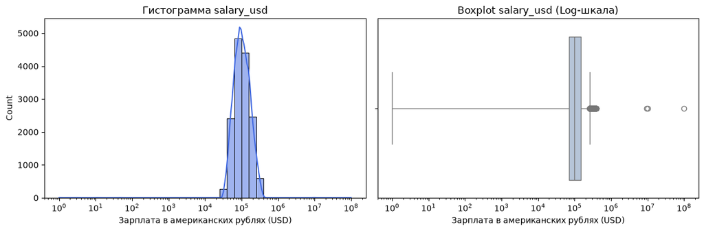

```python
import matplotlib.pyplot as plt
import seaborn as sns
import pandas as pd
import matplotlib.ticker as ticker

df = pd.read_csv('ai_job_dataset_upd.csv', sep=';')

# Статистика по всем данным
print("Статистика salary_usd:")
print(df['salary_usd'].describe().apply(lambda x: f"{x:,.0f}"))
print(f"Пропуски: {df['salary_usd'].isna().sum()}")

# Исключаем отрицательные значения только для графика,
# ибо логарифм от отрицательного числа взять нельзя
plot_data = df[df['salary_usd'] > 0]['salary_usd']

fig, axes = plt.subplots(1, 2, figsize=(12, 4))

# Гистограмма с лог-шкалой
sns.histplot(plot_data, bins=40, kde=True, log_scale=True, ax=axes[0], color='royalblue')
axes[0].set_title('Гистограмма salary_usd')
axes[0].set_xlabel('Зарплата в американских рублях (USD)')

# Боксплот с лог-шкалой
sns.boxplot(x=plot_data, ax=axes[1], color='lightsteelblue')
axes[1].set_xscale('log')
axes[1].set_title('Boxplot salary_usd (Log-шкала)')
axes[1].set_xlabel('Зарплата в американских рублях (USD)')

plt.tight_layout()
plt.show()
```

**2.2 Анализ признака `years_experience`**

**Постановка задачи и выбор метода:** Анализ распределения требуемого опыта работы `years_experience`. Цель - оценить, какой стаж чаще всего ищут работодатели, и выявить аномалии. Признак количественный, поэтому используем гистограмму для оценки формы распределения, ящичковую диаграмму для поиска статистических выбросов и базовые описательные статистики.

```
--- Описательная статистика years_experience ---
count    15,000.00
mean          6.25
std           5.55
min           0.00
25%           2.00
50%           5.00
75%          10.00
max          19.00
Name: years_experience, dtype: str
Количество пропусков: 0
```

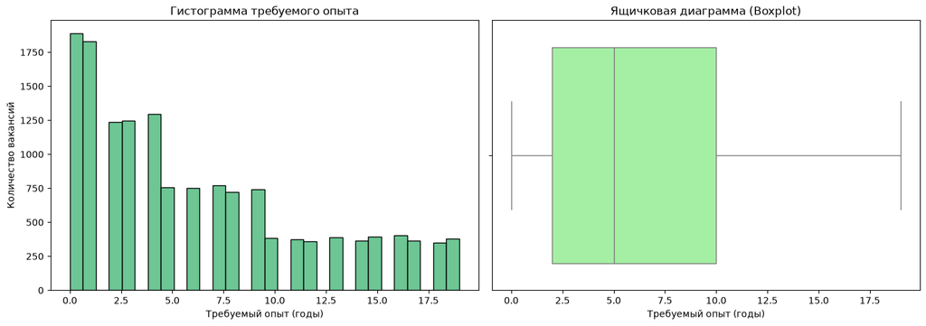

```python
import matplotlib.pyplot as plt
import seaborn as sns

# Описательные статистики
print("--- Описательная статистика years_experience ---")
print(df['years_experience'].describe().apply(lambda x: f"{x:,.2f}"))
print(f"Количество пропусков: {df['years_experience'].isna().sum()}")

fig, axes = plt.subplots(1, 2, figsize=(14, 5))

# Гистограмма
sns.histplot(df['years_experience'], bins=30, kde=False, ax=axes[0], color='mediumseagreen', edgecolor='black')
axes[0].set_title('Гистограмма требуемого опыта')
axes[0].set_xlabel('Требуемый опыт (годы)')
axes[0].set_ylabel('Количество вакансий')

# Ящик с усами
sns.boxplot(x=df['years_experience'], ax=axes[1], color='palegreen')
axes[1].set_title('Ящичковая диаграмма (Boxplot)')
axes[1].set_xlabel('Требуемый опыт (годы)')

plt.tight_layout()
plt.show()
```

**Интерпретация результатов:**

- **Что видим на первом графике с гистограммой:** Наибольшим спросом пользуются специалисты с минимальным опытом (от 0 до 2 лет) - здесь наблюдается самый высокий пик. Далее количество вакансий плавно снижается. После 10 лет опыта частота становится низкой, но стабильной вплоть до максимума в 19 лет.
- **Что видим на втором графике ящика с усами:** Основная масса требований лежит в диапазоне от 2 до 10 лет. Медианное значение требуемого опыта - 5 лет. Усы охватывают весь диапазон от 0 до 19 лет.
- **Выявленные аномалии:** Статистических выбросов на графике нет. Значения находятся в адекватных пределах, логических противоречий не выявлено. Пропусков нет.
- **Решение для предобработки:** Признак `years_experience` в текущем виде не содержит выбросов и пропусков, поэтому в дополнительной очистке или трансформации не нуждается.

**2.3 Анализ признака `benefits_score`**

**Постановка задачи и выбор метода:** По документации шкала должна быть от 1 до 10. Цель - проверить соответствие данных заявленной шкале и найти пропуски. Признак количественный. Построим гистограмму и боксплот для визуализации распределения и поиска возможных ошибок ввода.

```
--- Описательная статистика benefits_score ---
count    14984.000000
mean         8.171016
std         81.636659
min          5.000000
25%          6.200000
50%          7.500000
75%          8.800000
max       9999.000000
Name: benefits_score, dtype: float64
Количество пропусков: 16
```

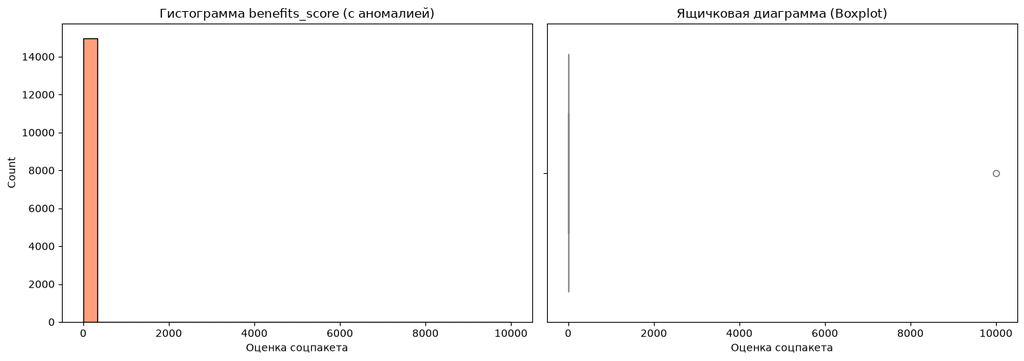

```python
import matplotlib.pyplot as plt
import seaborn as sns

print("--- Описательная статистика benefits_score ---")
print(df['benefits_score'].describe())
print(f"Количество пропусков: {df['benefits_score'].isna().sum()}")

fig, axes = plt.subplots(1, 2, figsize=(14, 5))

sns.histplot(df['benefits_score'], bins=30, ax=axes[0], color='coral', edgecolor='black')
axes[0].set_title('Гистограмма benefits_score (с аномалией)')
axes[0].set_xlabel('Оценка соцпакета')

sns.boxplot(x=df['benefits_score'], ax=axes[1], color='lightsalmon')
axes[1].set_title('Ящичковая диаграмма (Boxplot)')
axes[1].set_xlabel('Оценка соцпакета')

plt.tight_layout()
plt.show()
```

**Интерпретация результатов:**

- **Что видим на графиках:** Оба графика критически искажены из-за одного экстремального значения. На гистограмме все нормальные оценки сжались в один невидимый столбик около нуля, а на боксплоте сам «ящик» превратился в линию слева, в то время как справа далеко оторвана одна точка-выброс.
- **Выявленные аномалии:** Графики подтверждают наличие критической ошибки: максимальное значение равно $9999.0$, что грубо нарушает логику шкалы от 1 до 10. Также в признаке присутствует 16 пропусков.
- **Решение для предобработки:** Необходимо удалить выброс, заменив значение $9999.0$ на $NaN$. После этого все образовавшиеся пропуски целесообразно заполнить медианным значением (как лучший вариант, мб пересмотрено).

**2.4 Анализ признака `experience_level`**

**Постановка задачи и выбор метода:** Анализ распределения уровня опыта кандидатов: имеются такие EN, MI, SE, EX. Цель здесь - выявить, специалисты какого грейда формируют основную массу рынка ИИ, и оценить возможный дисбаланс классов. Признак является категориальным порядковым. Согласно методологии EDA, для таких данных меры центральной тенденции не применяются. Используем частотный анализ value_counts, а для визуализации - столбиковую и круговую диаграммы.

```
--- Частотный анализ experience_level ---
                  Абсолютная частота  Доля (%)
experience_level
MI                              3781      25.2
EX                              3760      25.1
SE                              3741      24.9
EN                              3718      24.8

Пропуски: 0
```

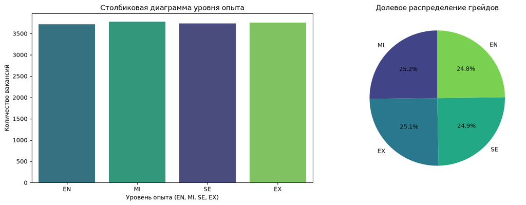

```python
import matplotlib.pyplot as plt
import seaborn as sns

# Частотный анализ
print("--- Частотный анализ experience_level ---")
freq_table = df['experience_level'].value_counts().to_frame(name='Абсолютная частота')
freq_table['Доля (%)'] = (df['experience_level'].value_counts(normalize=True) * 100).round(1)
print(freq_table)
print(f"\nПропуски: {df['experience_level'].isna().sum()}")

fig, axes = plt.subplots(1, 2, figsize=(14, 5))

# Столбиковая диаграмма
order = ['EN', 'MI', 'SE', 'EX']
sns.countplot(data=df, x='experience_level', hue='experience_level', order=order, ax=axes[0], palette='viridis', legend=False)
axes[0].set_title('Столбиковая диаграмма уровня опыта')
axes[0].set_xlabel('Уровень опыта (EN, MI, SE, EX)')
axes[0].set_ylabel('Количество вакансий')

# Круговая диаграмма
axes[1].pie(freq_table['Абсолютная частота'], labels=freq_table.index, autopct='%1.1f%%', startangle=90, colors=sns.color_palette('viridis', 4))
axes[1].set_title('Долевое распределение грейдов')

plt.tight_layout()
plt.show()
```

**Интерпретация результатов:**

- **Что видим в таблице и на графиках:** Распределение уровней опыта является практически идеально равномерным: на каждую из четырех категорий приходится около 25% вакансий.
- **Выявленные аномалии:** Такой идеальный баланс классов абсолютно нетипичен для реального рынка труда. Это свидетельствует о том, что данные - искуственная выборка, Алиса Валерьевна нашла идеальный рынок!

Технических ошибок и пропусков не обнаружено.

- **Решение для предобработки:** Для машинного обучения такой баланс классов - есть хорошо, модели не будут склоняться к какому-то одному классу. Так как признак имеет логическую иерархию, применим метод **Ordinal Encoding**, приемлимо заменить текст на числа. Например - EN=0, MI=1, SE=2, EX=3

**2.5 Анализ признака `remote_ratio`**

**Постановка задачи и выбор метода:** Анализ формата работы ( 0 - офис, 50 - гибрид, 100 - удаленка). Цель - оценить тренды форматов занятости. Хотя признак представлен числами, по своей сути он является категориальным и номинальным, тк принимает только три фиксированных значения. Этично применять частотный анализ и столбиковую диаграмму.

```
--- Частотный анализ remote_ratio ---
              Количество  Доля (%)
remote_ratio
0                   5075      33.8
50                  5005      33.4
100                 4920      32.8

Пропуски: 0
```

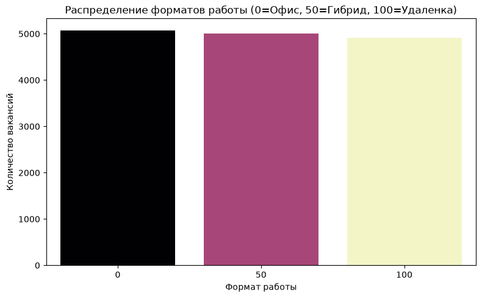

```python
import matplotlib.pyplot as plt
import seaborn as sns

# Частотный анализ
print("--- Частотный анализ remote_ratio ---")
freq_remote = df['remote_ratio'].value_counts().to_frame(name='Количество')
freq_remote['Доля (%)'] = (df['remote_ratio'].value_counts(normalize=True) * 100).round(1)
print(freq_remote)
print(f"\nПропуски: {df['remote_ratio'].isna().sum()}")

plt.figure(figsize=(8, 5))
sns.countplot(data=df, x='remote_ratio', hue='remote_ratio', palette='magma',
              order=[0, 50, 100], legend=False)
plt.title('Распределение форматов работы (0=Офис, 50=Гибрид, 100=Удаленка)')
plt.xlabel('Формат работы')
plt.ylabel('Количество вакансий')

plt.tight_layout()
plt.show()
```

**Интерпретация результатов:**

- **Что видим на графике и в таблице:** Наблюдается практически идеально равномерное распределение форматов работы: офис (33.8%), гибрид (33.4%) и полная удаленка (32.8%).
- **Выявленные аномалии:** Технических ошибок, недопустимых значений и пропусков не обнаружено. Однако, как и в случае с `experience_level`, идеальный баланс долей (33/33/33) указывает на искусственную балансировку датасета. На реальном рынке труда распределение форматов работы обычно сильно смещено в одну из сторон.
- **Решение для предобработки:** Данные представлены числовыми значениями (0, 50, 100), логически отражающими "процент удаленности". Их можно оставить без изменений. Для линейных алгоритмов может потребоваться применять One-Hot Encoding.

**3. Двумерный разведочный анализ данных (EDA). Часть 1: Корреляции и тренды**

**Постановка задачи:** Целевая переменная: `salary_usd`. Были выбраны предикторы: `years_experience`, `benefits_score`, `job_description_length`, `experience_level`, `company_size`. Необходимо выявить силу, направление и статистическую значимость связей между признаками, а также визуализировать влияние предикторов на зарплату.

**Обоснование выбора методов:**

1. **Коэффициент корреляции:** Так как числовые признаки: `salary_usd`, `years_experience` имеют скошенное распределение, а часть признаков (как `experience_level`, `company_size`) являются порядковыми , использование коэффициента Пирсона будет некорректным. Был выбран **коэффициент ранговой корреляции Спирмена**.
2. **Графики:**
   - *Матрица корреляций (Heatmap)* - для быстрой оценки мультиколлинеарности и связей с таргетом.
   - *Диаграмма рассеяния (Scatter)* -для оценки характера связи двух непрерывных/дискретных величин (--Зарплата + Опыт).
   - *Ящичковая диаграмма (Boxplot)* — для оценки распределения непрерывного таргета внутри категорий (--Зарплата + Уровень опыта).

```
--- Статистическая значимость корреляций с salary_usd (Спирмен) ---
years_experience: r = 0.791 | p-value = 0.000e+00 | Значима (p < 0.05)
benefits_score: r = -0.005 | p-value = 5.115e-01 | НЕ значима
job_description_length: r = -0.006 | p-value = 4.442e-01 | НЕ значима
exp_num: r = 0.815 | p-value = 0.000e+00 | Значима (p < 0.05)
size_num: r = 0.193 | p-value = 4.441e-126 | Значима (p < 0.05)
```

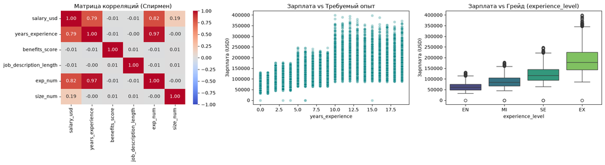

```python
import matplotlib.pyplot as plt
import seaborn as sns
import numpy as np
from scipy import stats

# 1. Подготовка данных - фильтруем аномалии ТОЛЬКО для EDA
df_eda = df[(df['salary_usd'] > 0) & (df['salary_usd'] < 500000) &
            (df['benefits_score'] <= 10)].copy()

# Для корреляции Спирмена переведем порядковые категории в числа
level_map = {'EN': 0, 'MI': 1, 'SE': 2, 'EX': 3}
size_map = {'S': 0, 'M': 1, 'L': 2}
df_eda['exp_num'] = df_eda['experience_level'].map(level_map)
df_eda['size_num'] = df_eda['company_size'].map(size_map)

cols_for_corr = ['salary_usd', 'years_experience', 'benefits_score',
                 'job_description_length', 'exp_num', 'size_num']

# 2. Расчет корреляций Спирмена и p-value
print("--- Статистическая значимость корреляций с salary_usd (Спирмен) ---")
for col in cols_for_corr[1:]:
    corr, p_val = stats.spearmanr(df_eda['salary_usd'], df_eda[col], nan_policy='omit')
    significance = "Значима (p < 0.05)" if p_val < 0.05 else "НЕ значима"
    print(f"{col}: r = {corr:.3f} | p-value = {p_val:.3e} | {significance}")

# 3. Визуализация
fig, axes = plt.subplots(1, 3, figsize=(18, 5))

# Хитмап
corr_matrix = df_eda[cols_for_corr].corr(method='spearman')
sns.heatmap(corr_matrix, annot=True, fmt='.2f', cmap='coolwarm', vmin=-1, vmax=1, ax=axes[0])
axes[0].set_title('Матрица корреляций (Спирмен)')

# Диаграмма рассеяния (Scatter plot)
sns.scatterplot(data=df_eda, x='years_experience', y='salary_usd', alpha=0.3, ax=axes[1], color='teal')
axes[1].set_title('Зарплата vs Требуемый опыт')
axes[1].set_ylabel('Зарплата (USD)')

# Боксплот по категориям
sns.boxplot(data=df_eda, x='experience_level', y='salary_usd', order=['EN', 'MI', 'SE', 'EX'], ax=axes[2], palette='viridis')
axes[2].set_title('Зарплата vs Грейд (experience_level)')
axes[2].set_ylabel('Зарплата (USD)')

plt.tight_layout()
plt.show()
```

**Интерпретация результатов:**

1. **Связь с целевой переменной salary_usd:**
   - Расчет p-value показал, что связи зарплаты с `years_experience`, `experience_level` и `company_size` статистически значимы ($p < 0.05$).
   - Наибольшую положительную корреляцию с зарплатой ожидаемо имеет грейд сотрудника (`exp_num`, $r = 0.82$) и требуемый опыт (`years_experience`, $r = 0.79$). Сила связи — **сильная**.
   - Размер компании `size_num` имеет слабую, но значимую связь ($r = 0.19$).
   - Признаки `benefits_score` и `job_description_length` имеют корреляцию близкую к нулю и $p-value > 0.05$. Связь с таргетом отсутствует.
2. **Закономерности на графиках:**
   - *Скаттерплот:* Наблюдается четкий ступенчатый тренд. При опыте >10 лет дисперсия зарплат сильно увеличивается. Появляется широкий разброс от 100т до почти 400т.
   - *Боксплот:* Четко виден рост медианной зарплаты при переходе от EN к MI, SE и EX. При этом у грейда EX самый большой межквартильный размах, что говорит о высокой вариативности компенсаций топ-менеджмента.
3. **Взаимосвязь предикторов:**
   - Между предикторами `years_experience` и `exp_num` выявлена **экстремально сильная прямая корреляция** ($r = 0.97$). Можно сказать эти два признака дублируют друг друга.

```
--- Таблица сопряженности: Уровень опыта vs Размер компании (в %) ---
```

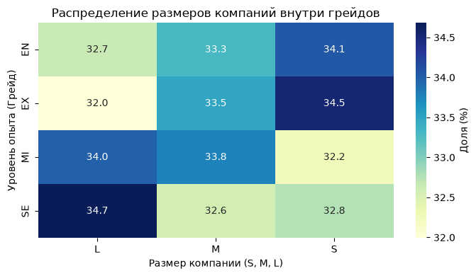

```python
print("--- Таблица сопряженности: Уровень опыта vs Размер компании (в %) ---")
# Строим таблицу и нормализуем по строкам - видеть распределение внутри каждого грейда
crosstab_data = pd.crosstab(df_eda['experience_level'], df_eda['company_size'], normalize='index') * 100

plt.figure(figsize=(7, 4))
sns.heatmap(crosstab_data, annot=True, fmt=".1f", cmap="YlGnBu", cbar_kws={'label': 'Доля (%)'})
plt.title('Распределение размеров компаний внутри грейдов')
plt.ylabel('Уровень опыта (Грейд)')
plt.xlabel('Размер компании (S, M, L)')
plt.tight_layout()
plt.show()
```

**Часть 2: Таблицы сопряженности и гипотезы** *Интерпретация результатов:*

1. **Таблица сопряженности:**
   - Анализ `experience_level` и `company_size` показывает практически абсолютно равномерное распределение.
   - Независимо от уровня, от EN до топ-менеджера EX, специалисты с одинаковой вероятностью встречаются в малых (S), средних (M) и крупных (L) компаниях.
   - **Вывод:** Это подтверждает нашу гипотезу из одномерного EDA (смотри! п. 2.4) об искусственной природе датасета. В реальном мире структура найма и распределение грейдов жестко зависят от размера бизнеса.
2. **Идеи для Feature Engineering:**
   - Из-за выявленной жесткой мультиколлинеарности ($r=0.97$) между опытом и грейдом, линейные модели будут работать некорректно. Идея: сделать бинаризацию, например, по флагу `is_senior_or_above` (1 - SE/EX, 0 - остальные), а непрерывный опыт оставить как есть.
   - Можно создать признак "соотношение зарплаты к среднему по рынку для данного грейда", чтобы выявлять аномально щедрые или жадные компании.
   - Признаки `benefits_score` и `job_description_length` можно исключить из обучения, ткк они не несут полезного сигнала для `salary_usd`.
3. **Гипотезы для построения моделей:**
   - *Гипотеза 1:* Главным драйвером зарплаты в ИИ является не столько количество лет опыта, сколько формальный грейд, так как корреляция `exp_num` с таргетом выше, чем у `years_experience`.
   - *Гипотеза 3:* Для улучшения качества будущих моделей потребуется применить методы снижения размерности типа **PCA** из 4 лекции, чтобы "схлопнуть" коррелирующие признаки опыта и грейда в одну главную компоненту.

**4. Предобработка данных**

По условию задания необходимо:

- Преобразовать форматы данных, если это требуется для анализа.
- Принять решение о способе обработки пропусков. Обосновать его и выполнить заполнение или удаление.
- Выявить выбросы. Обосновать решение об их корректировке или удалении и выполнить обработку.
- Применить разные виды масштабирования и трансформации как минимум к двум числовым признакам. Прокомментировать результаты.
- Преобразовать категориальный признак. Обосновать выбранный способ и объяснить результат.

Каждый шаг должен сопровождаться содержательным комментарием. Ниже приведены план обработки этого датасета, расчёты и выводы.

### 4.1. План обработки и рабочая копия

Продолжим анализ из пунктов 1–3. Целевая переменная: `salary_usd`.

План работы:

1. Преобразовать даты и привести варианты названий к единым категориям.
2. Обработать ошибки и подозрительные значения. Записать изменения в журнал.
3. Разделить данные на обучающую и отложенную части. Затем заполнить пропуски в признаках.
4. Сравнить три способа масштабирования и два нелинейных преобразования для двух числовых признаков.
5. Закодировать категории. В пункте 5 создать шесть признаков, проверить их связь с зарплатой и изучить PCA.

Используем методы из лекций: лекция 1, слайды 45–59 (разбиение и утечки); лекция 2, слайды 47–53 (корреляции); лекция 3, слайды 7–18, 26–45 (очистка, масштабирование и кодирование); лекция 4, слайды 8–30 (PCA). PDF доступны в [папке курса](https://disk.360.yandex.ru/d/k903xBTIzxMmVQ).

Для запуска положите `ai_job_dataset_upd.csv` рядом с ноутбуком. Зависимости указаны в `requirements.txt`. Выполняйте ячейки по порядку, начиная с первого пункта.

**Цель.** Подключить библиотеки и задать общие настройки расчётов. Ячейка показывает версии библиотек и определяет вспомогательные функции для поправки Холма, оформления таблиц и графиков.

```python
from pathlib import Path
import hashlib
import platform
import numpy as np
import pandas as pd
import matplotlib.pyplot as plt
import seaborn as sns
import scipy
from scipy import stats
import sklearn
from sklearn.model_selection import GroupShuffleSplit
from sklearn.preprocessing import (
    MinMaxScaler,
    StandardScaler,
    RobustScaler,
    OrdinalEncoder,
    OneHotEncoder,
)
from sklearn.impute import SimpleImputer
from sklearn.pipeline import Pipeline
from sklearn.compose import ColumnTransformer
from sklearn.decomposition import PCA
from IPython.display import display

RANDOM_STATE = 42
ALPHA = 0.05
LEVELS = ["EN", "MI", "SE", "EX"]
SIZES = ["S", "M", "L"]
LEVEL_MAP = dict(zip(LEVELS, range(4)))
SIZE_MAP = dict(zip(SIZES, range(3)))
BLUE, GOLD, GRAY = "#31688e", "#b98524", "#68727a"
sns.set_theme(style="whitegrid", font="DejaVu Sans", font_scale=1.02)
plt.rcParams.update({"figure.dpi": 110, "axes.spines.top": False, "axes.spines.right": False})
pd.set_option("display.max_columns", 12)
pd.set_option("display.max_rows", 25)
pd.set_option("display.float_format", lambda x: f"{x:,.3f}")


def holm(pvalues):
    """Поправка Холма для нескольких одновременных проверок."""
    pvalues = np.asarray(pvalues, dtype=float)
    order = np.argsort(pvalues)
    adjusted = np.empty(len(pvalues))
    previous = 0
    for rank, position in enumerate(order):
        corrected = (len(pvalues) - rank) * pvalues[position]
        previous = max(previous, corrected)
        adjusted[position] = min(1, previous)
    return adjusted


def p_text(p):
    return "<1e-300" if p < 1e-300 else f"{p:.3g}"


def show_stats(table, pcols=()):
    formats = {c: p_text for c in pcols}
    display(table.style.format(formats, precision=3, thousands=" "))


def finish():
    plt.tight_layout()
    plt.show()


display(
    pd.Series(
        {
            "Python": platform.python_version(),
            "pandas": pd.__version__,
            "NumPy": np.__version__,
            "SciPy": scipy.__version__,
            "scikit-learn": sklearn.__version__,
            "seaborn": sns.__version__,
        },
        name="Версия",
    )
)
```

```
Python               3.11.5
pandas                2.2.1
NumPy                1.26.4
SciPy                1.11.4
scikit-learn    1.4.1.post1
seaborn              0.13.2
Name: Версия, dtype: object
```

**Цель.** Проверить исходный CSV и создать рабочую копию. Таблицы сравниваются целиком, подсчитываются дубликаты. Крайние зарплаты показываются отдельно для поиска аномалий. Контрольная сумма сохраняется для проверки файла в конце.

```python
raw = df.copy(deep=True)
DATA_PATH = Path("ai_job_dataset_upd.csv")
source_sha256 = hashlib.sha256(DATA_PATH.read_bytes()).hexdigest()
source_matches = raw.equals(pd.read_csv(DATA_PATH, sep=";"))
print("Рабочая копия совпадает с CSV:", source_matches)
print("Размер таблицы:", raw.shape)
print("Полные дубликаты:", raw.duplicated().sum())
print("Повторы job_id:", raw.job_id.duplicated().sum())

# Крайние значения показывают разрывы в годовых зарплатах.
salary_edges = pd.DataFrame(
    {
        "Нижний край, USD/год": raw.salary_usd.nsmallest(14).to_numpy(),
        "Верхний край, USD/год": raw.salary_usd.nlargest(14).to_numpy(),
    }
)
display(salary_edges)
```

```
Рабочая копия совпадает с CSV: True
Размер таблицы: (15000, 19)
Полные дубликаты: 0
Повторы job_id: 0
```

|  | Нижний край, USD/год | Верхний край, USD/год |
| --- | --- | --- |
| 0 | -999.000 | 99,999,999.000 |
| 1 | -78.000 | 10,000,000.000 |
| 2 | -1.000 | 9,383,302.000 |
| 3 | 0.000 | 399,095.000 |
| 4 | 0.000 | 398,084.000 |
| 5 | 1.000 | 394,917.000 |
| 6 | 3.000 | 390,292.000 |
| 7 | 5.000 | 388,754.000 |
| 8 | 10.000 | 383,142.000 |
| 9 | 12.000 | 381,575.000 |
| 10 | 45.000 | 379,418.000 |
| 11 | 32,519.000 | 372,206.000 |
| 12 | 32,542.000 | 371,087.000 |
| 13 | 32,587.000 | 370,038.000 |

**Правила очистки.** Дубликатов нет. Удаляем пробелы по краям строк, заменяем US и UK полными названиями стран. Приводим отрасли к единым категориям, считаем `Ph` сокращением от `PhD`. Опираемся на имеющийся словарь. Значение кодов `8888`, `9999` и `6` неизвестно, поэтому ставим пропуски.

`salary_usd` содержит **годовую зарплату в долларах США**. Нулевые и отрицательные значения не используем. После 1, 3, 5, 10, 12 и 45 USD следующая зарплата равна 32 519 USD. В верхнем хвосте после 399 095 USD идут 9 383 302, 10 000 000 и 99 999 999 USD. Разрывы видны в таблице выше.

Для этого файла подозрительными считаем зарплаты **ниже 10 000 или не ниже 500 000 USD в год**. Это рабочие границы поиска аномалий, а не допустимые зарплаты на рынке. Они отделяют единицы долларов и три многомиллионных значения от основной группы. Для анализа оставляем **10 000 ≤ salary_usd < 500 000** и ниже проверяем другие границы. Само прохождение фильтра ещё не подтверждает достоверность записи.

Правильные значения неизвестны. Не домножаем зарплаты на 12 или 1 000 и не подставляем среднее. Ставим `NaN` в рабочей копии. Исходные значения остаются в CSV и журнале изменений: при появлении первоисточника их можно проверить. Выход за усы ящичной диаграммы сам по себе не повод удалять запись.

Балл соцпакета по словарю должен быть от 1 до 10. Для длины описания принимаем рабочий диапазон от 10 до 1 000 000 символов. Отрицательная длина невозможна, а 0, 1 или 6 символов выглядят сомнительно. Многомиллионные значения тоже сильно отличаются от остальных. Восстановить их нельзя, поэтому ставим `NaN`. Исходный `df` сохраняем, изменения записываем в журнал.

**Цель.** Применить правила очистки: исправить категории, преобразовать даты, заменить сомнительные числа пропусками. Изменения записываются в журнал. Проверки категорий, стажа и дат сохраняются в `data_checks` и выводятся в конце работы.

```python
SALARY_MIN = 10_000  # USD в год; рабочая граница поиска аномалий.
SALARY_CAP = 500_000  # Допущение для основного анализа, не универсальный предел оплаты.
checked = raw.copy(deep=True)
changes = []


def record_replace(column, new_values, reason):
    old = checked[column].copy()
    changed = ~((old == new_values) | (old.isna() & new_values.isna()))
    for idx in checked.index[changed.fillna(True)]:
        changes.append(
            {
                "job_id": checked.at[idx, "job_id"],
                "column": column,
                "before": str(old.at[idx]),
                "after": str(new_values.at[idx]),
                "reason": reason,
            }
        )
    checked[column] = new_values


for col in checked.select_dtypes("object"):
    record_replace(col, checked[col].str.strip(), "Пробелы по краям строки")
aliases = {
    "employee_residence": {"US": "United States", "UK": "United Kingdom", "8888": np.nan},
    "education_required": {"Associate.": "Associate", "Ph": "PhD", "6": np.nan},
    "industry": {
        "Retail_": "Retail",
        "manufacturing": "Manufacturing",
        "Transport": "Transportation",
        "Governmnt": "Government",
        "Telecom": "Telecommunications",
        "9999": np.nan,
    },
}
for col, mapping in aliases.items():
    record_replace(col, checked[col].replace(mapping), "Явный словарь исправлений")

for col in ["posting_date", "application_deadline"]:
    checked[col] = pd.to_datetime(checked[col], format="%Y-%m-%d", errors="coerce")

numeric_invalid = {
    "salary_usd": (checked.salary_usd < SALARY_MIN) | (checked.salary_usd >= SALARY_CAP),
    "benefits_score": checked.benefits_score.notna() & ~checked.benefits_score.between(1, 10),
    "job_description_length": checked.job_description_length.notna()
    & ~checked.job_description_length.between(10, 1_000_000),
}
for col, mask in numeric_invalid.items():
    record_replace(
        col, checked[col].mask(mask), "Недопустимо или подозрительно по объявленному правилу"
    )

audit = pd.DataFrame(changes)
display(audit.groupby(["column", "reason"]).size().rename("Изменений").to_frame())
display(audit[audit.column.isin(numeric_invalid)][["job_id", "column", "before", "after"]])
salary_valid = checked.salary_usd.dropna()
education_levels = ["Associate", "Bachelor", "Master", "PhD"]
data_checks = {
    "Нет повторов job_id": checked.job_id.is_unique,
    "Грейды есть в словаре": checked.experience_level.isin(LEVELS).all(),
    "Размеры компаний есть в словаре": checked.company_size.isin(SIZES).all(),
    "Формат работы имеет известный код": checked.remote_ratio.isin([0, 50, 100]).all(),
    "Уровни образования есть в словаре": checked.education_required.dropna()
    .isin(education_levels)
    .all(),
    "Стаж находится между 0 и 60 годами": checked.years_experience.between(0, 60).all(),
    "Дедлайн не раньше публикации": (
        checked.application_deadline >= checked.posting_date
    ).all(),
}
```

| column | reason | Изменений |
| --- | --- | --- |
| benefits_score | Недопустимо или подозрительно по объявленному правилу | 1 |
| education_required | Пробелы по краям строки | 1 |
|  | Явный словарь исправлений | 3 |
| employee_residence | Пробелы по краям строки | 1 |
|  | Явный словарь исправлений | 3 |
| industry | Пробелы по краям строки | 2 |
|  | Явный словарь исправлений | 6 |
| job_description_length | Недопустимо или подозрительно по объявленному правилу | 6 |
| salary_usd | Недопустимо или подозрительно по объявленному правилу | 14 |

|  | job_id | column | before | after |
| --- | --- | --- | --- | --- |
| 16 | AI00123 | salary_usd | 10.0 | nan |
| 17 | AI00192 | salary_usd | -78.0 | nan |
| 18 | AI00258 | salary_usd | 99999999.0 | nan |
| 19 | AI00638 | salary_usd | 3.0 | nan |
| 20 | AI00703 | salary_usd | 5.0 | nan |
| 21 | AI00795 | salary_usd | -999.0 | nan |
| 22 | AI00947 | salary_usd | 10000000.0 | nan |
| 23 | AI01451 | salary_usd | 45.0 | nan |
| 24 | AI01856 | salary_usd | 12.0 | nan |
| 25 | AI02040 | salary_usd | -1.0 | nan |
| 26 | AI02223 | salary_usd | 9383302.0 | nan |
| 27 | AI02421 | salary_usd | 1.0 | nan |
| 28 | AI02528 | salary_usd | 0.0 | nan |
| 29 | AI02714 | salary_usd | 0.0 | nan |
| 30 | AI10988 | benefits_score | 9999.0 | nan |
| 31 | AI09636 | job_description_length | 1.0 | nan |
| 32 | AI09643 | job_description_length | 0.0 | nan |
| 33 | AI09782 | job_description_length | 6.0 | nan |
| 34 | AI09848 | job_description_length | 9999999.0 | nan |
| 35 | AI13048 | job_description_length | 999999999.0 | nan |
| 36 | AI13051 | job_description_length | -3.0 | nan |

**Цель.** Проверить последствия очистки. Ячейка сравнивает число пропусков до и после обработки, показывает исправленные категории и диапазоны дат. Отдельно подсчитываются вакансии с дедлайном раньше даты публикации.

```python
display(
    pd.DataFrame(
        {"До обработки": raw.isna().sum(), "После проверки": checked.isna().sum()}
    ).loc[lambda t: t.sum(axis=1) > 0]
)
display(audit.loc[audit.column.isin(["employee_residence", "education_required", "industry"])])
date_summary = pd.DataFrame(
    {
        c: [checked[c].min(), checked[c].max(), checked[c].isna().sum()]
        for c in ["posting_date", "application_deadline"]
    },
    index=["Минимум", "Максимум", "Пропуски"],
)
display(date_summary)
print(
    "Дедлайн раньше публикации:", (checked.application_deadline < checked.posting_date).sum()
)
```

|  | До обработки | После проверки |
| --- | --- | --- |
| salary_usd | 10 | 24 |
| employee_residence | 2 | 3 |
| education_required | 5 | 6 |
| industry | 3 | 4 |
| job_description_length | 8 | 14 |
| benefits_score | 16 | 17 |

|  | job_id | column | before | after | reason |
| --- | --- | --- | --- | --- | --- |
| 0 | AI10023 | employee_residence | United States | United States | Пробелы по краям строки |
| 1 | AI05962 | education_required | Associate. | Associate. | Пробелы по краям строки |
| 2 | AI00192 | industry | Government | Government | Пробелы по краям строки |
| 3 | AI05867 | industry | Retail | Retail | Пробелы по краям строки |
| 4 | AI10035 | employee_residence | US | United States | Явный словарь исправлений |
| 5 | AI10120 | employee_residence | UK | United Kingdom | Явный словарь исправлений |
| 6 | AI10262 | employee_residence | 8888 | nan | Явный словарь исправлений |
| 7 | AI00097 | education_required | 6 | nan | Явный словарь исправлений |
| 8 | AI05962 | education_required | Associate. | Associate | Явный словарь исправлений |
| 9 | AI06006 | education_required | Ph | PhD | Явный словарь исправлений |
| 10 | AI00253 | industry | Retail_ | Retail | Явный словарь исправлений |
| 11 | AI00442 | industry | manufacturing | Manufacturing | Явный словарь исправлений |
| 12 | AI00519 | industry | Transport | Transportation | Явный словарь исправлений |
| 13 | AI00927 | industry | Governmnt | Government | Явный словарь исправлений |
| 14 | AI06095 | industry | Telecom | Telecommunications | Явный словарь исправлений |
| 15 | AI06513 | industry | 9999 | nan | Явный словарь исправлений |

|  | posting_date | application_deadline |
| --- | --- | --- |
| Минимум | 2024-01-01 00:00:00 | 2024-01-16 00:00:00 |
| Максимум | 2025-04-30 00:00:00 | 2025-07-11 00:00:00 |
| Пропуски | 0 | 0 |

```
Дедлайн раньше публикации: 0
```

После обработки для анализа сохранена зарплата 14 976 вакансий. Неизвестная или сомнительная зарплата: 24 строки. Пропусков в балле соцпакета: 17. Пропусков в длине описания: 14.

Даты преобразованы успешно. Срок подачи заявок нигде не заканчивается раньше публикации. В файле есть вакансии за 2024 год и январь–апрель 2025 года. Используем весь выданный файл. По нему нельзя оценить весь рынок за 2025 год. После исправлений US и United States относятся к одной стране. Аналогично объединены другие варианты категорий.

### 4.2. Проверка порога зарплат

Сравним несколько нижних и верхних порогов. Отдельно сохраним все положительные зарплаты. Посмотрим, как меняются статистики. Качество прогноза здесь не оценивается.

**Цель.** Проверить чувствительность выводов к границам зарплаты. Для четырёх вариантов отбора сравниваются число строк, среднее, медиана и корреляция Спирмена со стажем.

```python
variants = [
    ("Все положительные", 0, np.inf),
    ("Основной: 10 000–500 000", 10_000, 500_000),
    ("Шире: 5 000–1 000 000", 5_000, 1_000_000),
    ("Выше нижняя граница: 30 000–500 000", 30_000, 500_000),
]
sensitivity_rows = []
for name, lower, upper in variants:
    selected_rows = (raw.salary_usd > 0) & (raw.salary_usd >= lower) & (raw.salary_usd < upper)
    part = raw.loc[selected_rows]
    correlation = stats.spearmanr(part.salary_usd, part.years_experience).statistic
    sensitivity_rows.append(
        {
            "Вариант, USD/год": name,
            "Строки": len(part),
            "Среднее, USD/год": part.salary_usd.mean(),
            "Медиана, USD/год": part.salary_usd.median(),
            "ρ зарплаты и стажа": correlation,
        }
    )
sensitivity = pd.DataFrame(sensitivity_rows).set_index("Вариант, USD/год")
display(sensitivity)
```

| Вариант, USD/год | Строки | Среднее, USD/год | Медиана, USD/год | ρ зарплаты и стажа |
| --- | --- | --- | --- | --- |
| Все положительные | 14985 | 123,248.049 | 99,642.000 | 0.791 |
| Основной: 10 000–500 000 | 14976 | 115,350.470 | 99,658.500 | 0.792 |
| Шире: 5 000–1 000 000 | 14976 | 115,350.470 | 99,658.500 | 0.792 |
| Выше нижняя граница: 30 000–500 000 | 14976 | 115,350.470 | 99,658.500 | 0.792 |

При сохранении всех положительных зарплат среднее равно 123 248 USD. При основном варианте отбора оно равно 115 350 USD. Медиана после обработки составляет 99 658,5 USD. Связь зарплаты со стажем почти не меняется: ρ = 0,792.

Варианты 5 000–1 000 000, 10 000–500 000 и 30 000–500 000 USD в год оставляют одинаковые 14 976 строк. Пороги попадают в разрывы между группами зарплат, поэтому здесь выбор конкретной границы не влияет на результат. Три экстремальные зарплаты заметно меняют среднее. Медиана и ранговая корреляция устойчивее. Исключение этих строк остаётся нашим допущением. Если появится доступ к первоисточнику, значения нужно проверить.

### 4.3. Пропуски и разделение данных

В `benefits_score` и `job_description_length` заполняем пропуски медианами обучающей части. Добавляем индикаторы, которые показывают, где значение отсутствовало. Для пропусков в категориях используем `Unknown`. Так мы не приписываем записи выдуманную категорию.

**Пропуски в `salary_usd` не заполняем.** Иначе при обучении модель получила бы придуманный правильный ответ. Строки без используемой в анализе зарплаты сохраняем отдельно. Позже для них можно будет получить прогноз. При расчёте корреляций используем только пары с известными значениями.

До обучения преобразований делим данные по названиям компаний. В отложенную часть попадают 20% из 16 названий с округлением вверх: четыре компании. Это около 25% строк. Названия компаний между частями не пересекаются. Названия могут быть условными, поэтому независимость работодателей не гарантирована. Разбиение позволяет проверить применение преобразований к новым данным. Для независимой оценки качества модели оно не подходит: предыдущий анализ уже использовал весь файл.

На слайде 45 лекции 3 есть правило: «обучаем (fit) все шаги предобработки только на train». Поэтому мы считаем медианы и параметры масштабирования на обучающей части, а к отложенной применяем уже готовые преобразования. Здесь держим себя в руках: в test за подсказками не заглядываем.

**Цель.** Разделить данные по компаниям с помощью `GroupShuffleSplit`. Строки без используемой зарплаты сохранить отдельно. Проверить учёт всех строк и отсутствие общих компаний и вакансий между частями.

```python
usable = checked.loc[checked.salary_usd.notna()].copy()
unlabeled = checked.loc[checked.salary_usd.isna()].copy()
splitter = GroupShuffleSplit(n_splits=1, test_size=0.2, random_state=RANDOM_STATE)
train_pos, test_pos = next(splitter.split(usable, groups=usable.company_name))
train = usable.iloc[train_pos].copy()
test = usable.iloc[test_pos].copy()
display(
    pd.DataFrame(
        {
            "Строки": [len(raw), len(usable), len(unlabeled), len(train), len(test)],
            "Описание": [
                "Исходник",
                "Наблюдаемая цель",
                "Неизвестная цель",
                "Обучающая часть",
                "Отложенная часть",
            ],
        }
    )
)
```

|  | Строки | Описание |
| --- | --- | --- |
| 0 | 15000 | Исходник |
| 1 | 14976 | Наблюдаемая цель |
| 2 | 24 | Неизвестная цель |
| 3 | 11195 | Обучающая часть |
| 4 | 3781 | Отложенная часть |

Обучающая часть: 11 195 строк, число компаний: 12. Отложенная часть: 3 781 строка, число компаний: 4. Без используемой в анализе зарплаты: 24 строки. Они сохранены отдельно. Пересечений job_id и названий компаний нет.

Медиана устойчива к крайним значениям, но заполнение пропусков уменьшает разброс. Истинные значения при этом остаются неизвестными. Поэтому заполненные данные используем для подготовки матрицы, а связи изучаем по исходно известным парам. Даже редкие пропуски могут возникать закономерно. Их индикаторы сохраняют эту информацию для модели.

### 4.4. Масштабирование двух числовых признаков

Для `years_experience` и `job_description_length` сравним MinMaxScaler, StandardScaler и RobustScaler. В каждом `Pipeline` сначала заполняем пропуски медианой, затем меняем масштаб. Параметры определяем только по обучающей части. Все три преобразования линейны. Они меняют шкалу, но **не делают распределение нормальным**. Зарплату в матрицу признаков не включаем.

**Цель.** Сравнить три способа масштабирования двух признаков. Параметры оцениваются на train и применяются к test. Таблица показывает средние, диапазоны и разброс. Гистограммы не повторяем: их форма сохраняется.

```python
scale_columns = ["years_experience", "job_description_length"]
scalers = {"Min-Max": MinMaxScaler(), "Standard": StandardScaler(), "Robust": RobustScaler()}
scaled_train, scaled_test = {}, {}
scale_pipelines = {}
scale_rows = []
for name, scaler in scalers.items():
    pipe = Pipeline([("imputer", SimpleImputer(strategy="median")), ("scaler", scaler)])
    a = pipe.fit_transform(train[scale_columns])
    b = pipe.transform(test[scale_columns])
    scaled_train[name] = pd.DataFrame(a, index=train.index, columns=scale_columns)
    scaled_test[name] = pd.DataFrame(b, index=test.index, columns=scale_columns)
    scale_pipelines[name] = pipe
    for col in scale_columns:
        for split, data in [("train", scaled_train[name]), ("test", scaled_test[name])]:
            x = data[col]
            scale_rows.append(
                {
                    "Метод": name,
                    "Часть": split,
                    "Признак": col,
                    "Среднее": x.mean(),
                    "SD (ddof=0)": x.std(ddof=0),
                    "Медиана": x.median(),
                    "IQR": x.quantile(0.75) - x.quantile(0.25),
                    "min": x.min(),
                    "max": x.max(),
                }
            )
scale_summary = pd.DataFrame(scale_rows)
display(scale_summary)
```

|  | Метод | Часть | Признак | Среднее | SD (ddof=0) | Медиана | IQR | min | max |
| --- | --- | --- | --- | --- | --- | --- | --- | --- | --- |
| 0 | Min-Max | train | years_experience | 0.333 | 0.292 | 0.263 | 0.421 | 0.000 | 1.000 |
| 1 | Min-Max | test | years_experience | 0.317 | 0.290 | 0.211 | 0.421 | 0.000 | 1.000 |
| 2 | Min-Max | train | job_description_length | 0.503 | 0.288 | 0.506 | 0.498 | 0.000 | 1.000 |
| 3 | Min-Max | test | job_description_length | 0.499 | 0.289 | 0.506 | 0.498 | 0.000 | 1.000 |
| 4 | Standard | train | years_experience | 0.000 | 1.000 | -0.239 | 1.440 | -1.139 | 2.280 |
| 5 | Standard | test | years_experience | -0.055 | 0.991 | -0.419 | 1.440 | -1.139 | 2.280 |
| 6 | Standard | train | job_description_length | -0.000 | 1.000 | 0.012 | 1.730 | -1.746 | 1.727 |
| 7 | Standard | test | job_description_length | -0.012 | 1.002 | 0.010 | 1.729 | -1.746 | 1.727 |
| 8 | Robust | train | years_experience | 0.166 | 0.695 | 0.000 | 1.000 | -0.625 | 1.750 |
| 9 | Robust | test | years_experience | 0.128 | 0.688 | -0.125 | 1.000 | -0.625 | 1.750 |
| 10 | Robust | train | job_description_length | -0.007 | 0.578 | 0.000 | 1.000 | -1.016 | 0.991 |
| 11 | Robust | test | job_description_length | -0.014 | 0.579 | -0.001 | 0.999 | -1.016 | 0.991 |

На обучающей части MinMaxScaler даёт диапазон от 0 до 1. После StandardScaler среднее равно 0, стандартное отклонение равно 1. После RobustScaler медиана равна 0, межквартильный размах равен 1.

В отложенной части эти свойства могут не сохраняться. Если новое значение выходит за обучающий диапазон, MinMaxScaler может дать число меньше 0 или больше 1. Линейные преобразования сохраняют форму распределения, поэтому здесь достаточно таблицы.

Для PCA ниже используем StandardScaler. Так длина описания не будет преобладать из-за больших численных значений. RobustScaler полезен, если допустимые крайние значения сохранены. Ошибки в данных всё равно нужно обрабатывать отдельно.

### 4.5. Нелинейные преобразования: log1p и квадратный корень

Для тех же двух признаков сравним исходную шкалу, `log1p(x)` и `sqrt(x)`. Все значения неотрицательны. Рассчитаем асимметрию и эксцесс. У этих преобразований нет подбираемых параметров. Медианы для заполнения пропусков уже получены на обучающей части. Уменьшение асимметрии само по себе не гарантирует улучшения прогноза.

**Цель.** Сравнить асимметрию и эксцесс двух признаков до и после `log1p` и извлечения квадратного корня. Две гистограммы иллюстрируют изменение формы распределения стажа после `log1p`. Результаты всех шести вариантов приведены в таблице.

| Признак | Метод | Асимметрия | Эксцесс |
| --- | --- | --- | --- |
| years_experience | Исходный | 0.761 | -0.556 |
|  | log1p | -0.364 | -0.921 |
|  | sqrt | -0.112 | -0.863 |
| job_description_length | Исходный | -0.014 | -1.197 |
|  | log1p | -0.566 | -0.752 |
|  | sqrt | -0.277 | -1.072 |

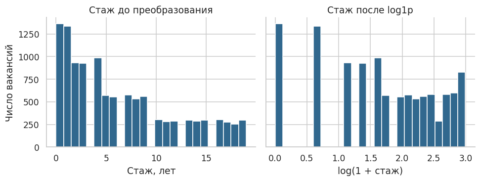

```python
imputer = scale_pipelines["Standard"].named_steps["imputer"]
imputed_train = imputer.transform(train[scale_columns])
imputed_test = imputer.transform(test[scale_columns])
transforms = {"Исходный": lambda x: x, "log1p": np.log1p, "sqrt": np.sqrt}
transform_rows = []
for column_number, column in enumerate(scale_columns):
    for name, transform in transforms.items():
        values = transform(imputed_train[:, column_number])
        transform_rows.append(
            {
                "Признак": column,
                "Метод": name,
                "Асимметрия": stats.skew(values, bias=False),
                "Эксцесс": stats.kurtosis(values, bias=False),
            }
        )
transform_summary = pd.DataFrame(transform_rows).set_index(["Признак", "Метод"])
display(transform_summary)

# Для иллюстрации изменения формы достаточно стажа до и после log1p.
experience = imputed_train[:, 0]
fig, axes = plt.subplots(1, 2, figsize=(9, 3.5), sharey=True)
axes[0].hist(experience, bins=25, color=BLUE)
axes[0].set(title="Стаж до преобразования", xlabel="Стаж, лет", ylabel="Число вакансий")
axes[1].hist(np.log1p(experience), bins=25, color=BLUE)
axes[1].set(title="Стаж после log1p", xlabel="log(1 + стаж)")
finish()
log_train = np.log1p(imputed_train)
log_test = np.log1p(imputed_test)
```

years_experience: исходная асимметрия 0.76, log1p -0.36, sqrt -0.11; job_description_length: исходная асимметрия -0.01, log1p -0.57, sqrt -0.28.

Для стажа оба преобразования уменьшают правую асимметрию. Длина описания после очистки распределена примерно равномерно. Логарифм создаёт отрицательную асимметрию. Поэтому автоматически применять его к длине описания не будем. В основной матрице оставляем исходные числовые признаки и стандартизируем их. Для нулевого стажа подходит log1p, поскольку обычный log(0) не определён.

### 4.6. Кодирование категорий

Сначала покажем порядковое кодирование: EN < MI < SE < EX и S < M < L. Числовые коды сохраняют порядок. Равные расстояния между категориями из этого не следуют.

В основной матрице используем one-hot encoding (OHE), в том числе для грейда. При таком кодировании линейная модель сможет оценить отдельный эффект каждой категории. Образование тоже кодируем через OHE: категорию `Unknown` нельзя поставить на определённую ступень образования.

`job_id` и `company_name` в признаки не включаем. Название компании нужно только для разбиения данных. Из навыков и дат создадим новые признаки в пункте 5.

**Цель.** Показать порядковое кодирование и `OHE`. Обработчик обучается на train и преобразует обе части. Итоговые проверки контролируют состав столбцов, пропуски и исключение зарплаты и идентификаторов.

```python
ordinal = OrdinalEncoder(
    categories=[LEVELS, SIZES], handle_unknown="use_encoded_value", unknown_value=-1
)
ordinal_train = ordinal.fit_transform(train[["experience_level", "company_size"]])
ordinal_test = ordinal.transform(test[["experience_level", "company_size"]])
display(pd.DataFrame({"Грейд": LEVELS, "Код": [0, 1, 2, 3]}))
display(pd.DataFrame({"Размер": SIZES, "Код": [0, 1, 2]}))
remote_encoder = OneHotEncoder(sparse_output=False, handle_unknown="ignore", dtype=int)
remote_encoder.fit(train[["remote_ratio"]])
display(
    pd.DataFrame(
        remote_encoder.transform(pd.DataFrame({"remote_ratio": [0, 50, 100]})),
        columns=remote_encoder.get_feature_names_out(),
        index=["Офис", "Гибрид", "Удалённо"],
    )
)

base_numeric = ["years_experience", "benefits_score", "job_description_length"]
base_categorical = [
    "experience_level",
    "company_size",
    "remote_ratio",
    "education_required",
    "industry",
    "employee_residence",
    "company_location",
    "employment_type",
    "job_title",
    "salary_currency",
]


def make_preprocessor(numeric, categorical):
    numeric_steps = Pipeline(
        [
            ("imputer", SimpleImputer(strategy="median", add_indicator=True)),
            ("scaler", StandardScaler()),
        ]
    )
    category_steps = Pipeline(
        [
            ("imputer", SimpleImputer(strategy="constant", fill_value="Unknown")),
            ("encoder", OneHotEncoder(handle_unknown="ignore", sparse_output=False)),
        ]
    )
    return ColumnTransformer(
        [
            ("numeric", numeric_steps, numeric),
            ("category", category_steps, categorical),
        ],
        remainder="drop",
        verbose_feature_names_out=True,
    )


base_preprocessor = make_preprocessor(base_numeric, base_categorical)
X_train_base = base_preprocessor.fit_transform(train)
X_test_base = base_preprocessor.transform(test)
base_feature_names = base_preprocessor.get_feature_names_out()
print("Матрица train:", X_train_base.shape, "; отложенная:", X_test_base.shape)
display(pd.DataFrame(X_train_base[:5, :8], columns=base_feature_names[:8]))
```

|  | Грейд | Код |
| --- | --- | --- |
| 0 | EN | 0 |
| 1 | MI | 1 |
| 2 | SE | 2 |
| 3 | EX | 3 |

|  | Размер | Код |
| --- | --- | --- |
| 0 | S | 0 |
| 1 | M | 1 |
| 2 | L | 2 |

|  | remote_ratio_0 | remote_ratio_50 | remote_ratio_100 |
| --- | --- | --- | --- |
| Офис | 1 | 0 | 0 |
| Гибрид | 0 | 1 | 0 |
| Удалённо | 0 | 0 | 1 |

```
Матрица train: (11195, 104) ; отложенная: (3781, 104)
```

|  | numeric__years_experience | numeric__benefits_score | numeric__job_description_length | numeric__missingindicator_benefits_score | numeric__missingindicator_job_description_length | category__experience_level_EN | category__experience_level_EX | category__experience_level_MI |
| --- | --- | --- | --- | --- | --- | --- | --- | --- |
| 0 | -0.959 | -1.584 | -0.412 | -0.030 | -0.028 | 1.000 | 0.000 | 0.000 |
| 1 | -0.779 | 1.312 | 0.815 | -0.030 | -0.028 | 0.000 | 0.000 | 1.000 |
| 2 | 0.121 | 0.760 | -0.278 | -0.030 | -0.028 | 0.000 | 0.000 | 0.000 |
| 3 | 0.121 | -1.102 | -1.192 | -0.030 | -0.028 | 0.000 | 0.000 | 0.000 |
| 4 | -1.139 | 0.071 | -0.381 | -0.030 | -0.028 | 1.000 | 0.000 | 0.000 |

При OHE формата работы у каждой строки один активный столбец. Так модель рассматривает офис, гибрид и удалённую работу как отдельные категории.

Список категорий определяется по обучающей части. При `handle_unknown='ignore'` новая категория получает нули во всём своём блоке. При дальнейшем использовании модели стоит следить, как часто это происходит.

Для обычной линейной регрессии с константой можно убрать одну категорию через `drop='first'`, чтобы избежать линейной зависимости столбцов. В регуляризованной модели можно оставить все категории. Матрицы обеих частей имеют одинаковые столбцы, без пропусков и бесконечных значений.

**5. Конструирование признаков**

По условию задания необходимо:

- Создать не менее трёх новых признаков на основе имеющихся данных.
- Объяснить, какую информацию добавляет каждый признак и чем он может быть полезен.
- Исследовать связь новых признаков с выбранной целевой переменной.
- Описать закономерности и оценить возможную пользу признаков для будущих моделей.

Ниже созданы шесть признаков и разобраны результаты их проверки. Обучение моделей в этот пункт задания не входит. Поэтому возможное улучшение прогноза рассматривается как гипотеза.

### Как проверяются идеи из пункта 3

В маркдаун-ячейке 26 предложены признаки и гипотезы для будущих моделей. Посмотрим, что уже удалось проверить.

1. **Стаж, грейд и бинарный признак.** Сильная связь стажа с грейдом затрудняет интерпретацию коэффициентов линейной модели, но не делает её автоматически некорректной. Флаг `is_senior_or_above` можно сравнить с полным кодированием грейда. Он объединяет EN с MI и SE с EX, поэтому часть различий теряется. Связь со стажем тоже может сохраниться. Здесь создан `senior_large`: старший грейд SE/EX в крупной компании. Его связь с зарплатой разобрана в пунктах 5.2 и 5.3. Отдельный флаг старшего грейда в модели пока не проверялся.
2. **Зарплата относительно среднего по грейду.** Это полезно для поиска необычных вакансий, но среднее по учебному файлу не равно среднему по рынку. Для расчёта отношения нужна сама зарплата, которую предстоит предсказывать. Поэтому такой признак создаёт утечку и в матрицу не включён. В пункте 5.3 сравниваются групповые медианы для описания данных.
3. **Балл соцпакета и длина описания.** Слабая парная корреляция не доказывает бесполезность признака: он может работать вместе с другими. Оба признака сохранены. Исключать их стоит после сравнения моделей с ними и без них на одинаковых разбиениях.
4. **Грейд как главный фактор зарплаты.** Более высокая корреляция не доказывает причинного влияния или преимущества для прогноза. Потребуется сравнить модели со стажем, с грейдом и с обоими признаками. Здесь такой эксперимент не проводится.
5. **PCA для стажа и грейда.** В пункте 5.4 одна компонента сохраняет 96,27% дисперсии стандартизированной пары на train. Сжать два признака удалось. Улучшит ли это прогноз зарплаты, ещё нужно проверить: PCA не учитывает зарплату при выборе компонент. Пока оставляем его отдельным исследованием.

### 5.1. Шесть новых признаков

Все признаки рассчитаны без использования зарплаты. Предполагаем, что прогноз нужен для вакансии, поля которой уже известны.

| Признак | Расчёт | Возможная польза и ограничения |
| --- | --- | --- |
| application_window_days | Разница между датой окончания приёма и датой публикации, в днях | Плановый срок приёма заявок. Фактический срок найма может отличаться. |
| skill_count | Число уникальных непустых навыков | Число перечисленных требований. Список может быть неполным. |
| cross_border | Страны компании и сотрудника различаются | Географическое несовпадение. Гражданство и факт переезда неизвестны. |
| has_cloud_tools | В списке есть AWS, Azure или GCP | Требование облачных технологий. Уровень владения ими неизвестен. |
| senior_large | Грейд SE или EX при размере компании L | Сочетание старшего грейда и крупной компании. |
| years_experience_sq | Квадрат требуемого стажа | Позволяет простой модели описать нелинейную связь со стажем. |

Если одна из стран неизвестна, `cross_border` остаётся `NaN`. Иначе сравнение с `Unknown` могло бы ошибочно отметить различие стран. Если страна сотрудника ещё неизвестна при публикации, этот признак нельзя использовать для прогноза в тот момент. Срок приёма заявок тоже должен быть известен заранее.

**Цель.** Рассчитать шесть признаков и проверить их значения по описательной статистике. Затем перемешать зарплаты: новые признаки должны остаться прежними, поскольку их формулы не используют зарплату.

```python
new_columns = [
    "application_window_days",
    "skill_count",
    "cross_border",
    "has_cloud_tools",
    "senior_large",
    "years_experience_sq",
]


def create_features(frame):
    result = frame.copy()
    tokens = frame.required_skills.fillna("").map(
        lambda s: {x.strip().casefold() for x in s.split(",") if x.strip()}
    )
    result["application_window_days"] = (
        frame.application_deadline - frame.posting_date
    ).dt.days
    result["skill_count"] = tokens.map(len)
    countries_known = frame.company_location.notna() & frame.employee_residence.notna()
    result["cross_border"] = np.where(
        countries_known,
        (frame.company_location != frame.employee_residence).astype(float),
        np.nan,
    )
    result["has_cloud_tools"] = tokens.map(lambda s: int(bool(s & {"aws", "azure", "gcp"})))
    result["senior_large"] = (
        frame.experience_level.isin(["SE", "EX"]) & frame.company_size.eq("L")
    ).astype(int)
    result["years_experience_sq"] = frame.years_experience**2
    return result


features = create_features(checked)
feature_eda = features.loc[features.salary_usd.notna()]
train_fe = create_features(train)
test_fe = create_features(test)
display(features[new_columns].describe().T)
display(features[new_columns].isna().rename_axis("index").sum().to_frame("Пропуски"))
skill_counts = features.skill_count.value_counts().sort_index()
display(skill_counts.rename("Вакансий"))
# Проверка отсутствия зависимости производных признаков от целевой переменной.
shuffled_target = checked.copy()
shuffled_target["salary_usd"] = np.random.default_rng(RANDOM_STATE).permutation(
    checked.salary_usd
)
features_after_shuffle = create_features(shuffled_target)[new_columns]
features_ignore_salary = features_after_shuffle.equals(features[new_columns])
print("Новые признаки не зависят от перемешивания зарплаты:", features_ignore_salary)
```

|  | count | mean | std | min | 25% | 50% | 75% | max |
| --- | --- | --- | --- | --- | --- | --- | --- | --- |
| application_window_days | 15,000.000 | 43.546 | 17.325 | 14.000 | 29.000 | 44.000 | 59.000 | 74.000 |
| skill_count | 15,000.000 | 3.993 | 0.816 | 3.000 | 3.000 | 4.000 | 5.000 | 5.000 |
| cross_border | 14,997.000 | 0.284 | 0.451 | 0.000 | 0.000 | 0.000 | 1.000 | 1.000 |
| has_cloud_tools | 15,000.000 | 0.388 | 0.487 | 0.000 | 0.000 | 0.000 | 1.000 | 1.000 |
| senior_large | 15,000.000 | 0.167 | 0.373 | 0.000 | 0.000 | 0.000 | 0.000 | 1.000 |
| years_experience_sq | 15,000.000 | 69.856 | 97.609 | 0.000 | 4.000 | 25.000 | 100.000 | 361.000 |

|  | Пропуски |
| --- | --- |
| application_window_days | 0 |
| skill_count | 0 |
| cross_border | 3 |
| has_cloud_tools | 0 |
| senior_large | 0 |
| years_experience_sq | 0 |

```
skill_count
3    5050
4    5007
5    4943
Name: Вакансий, dtype: int64
```

```
Новые признаки не зависят от перемешивания зарплаты: True
```

Приём заявок длится от 14 до 74 дней. В `required_skills` указано от трёх до пяти навыков. Значит, «Top 5» в словаре не означает, что в каждой строке ровно пять записей. При подсчёте удаляем повторы внутри списка. Также учитываем различия в регистре и пробелах.

Квадрат стажа сохраняет порядок наблюдений. Его ранговая связь с зарплатой не показывает, добавляет ли он пользу по сравнению с исходным стажем. После перемешивания зарплаты все шесть признаков остались прежними. Это подтверждает, что расчёт не использует целевую переменную.

### 5.2. Связь новых признаков с зарплатой

Для числовых признаков с повторяющимися значениями используем коэффициент Кендалла τ-b. Для бинарных сравниваем распределения зарплаты тестом Манна–Уитни и рассчитываем рангово-бисериальную корреляцию. Положительный знак означает, что при значении признака 1 зарплата чаще выше. Тест Манна–Уитни без дополнительных условий нельзя считать проверкой равенства медиан.

Уровень значимости: 0,05. Проверки двусторонние, с поправкой Холма на шесть сравнений. Берём пары с известными значениями. Коэффициенты разных типов напрямую по величине не сравниваем.

Вакансии одной компании могут быть связаны, хотя расчёт p-value предполагает независимость строк. Поэтому осторожно переносим выводы за пределы файла. Отсутствие значимости не доказывает отсутствия связи.

**Цель.** Оценить связь новых признаков с зарплатой выбранными методами. Таблица показывает размеры выборок, эффекты и p-value. Поправка Холма учитывает шесть одновременных проверок.

```python
binary = ["cross_border", "has_cloud_tools", "senior_large"]
fe_rows = []
for col in new_columns:
    pair = feature_eda[[col, "salary_usd"]].dropna()
    if col in binary:
        one = pair.loc[pair[col] == 1, "salary_usd"]
        zero = pair.loc[pair[col] == 0, "salary_usd"]
        u, p = stats.mannwhitneyu(one, zero, alternative="two-sided", method="asymptotic")
        effect = 2 * u / (len(one) * len(zero)) - 1
        method = "Манн-Уитни / r_rb"
        delta = one.median() - zero.median()
    else:
        effect, p = stats.kendalltau(pair[col], pair.salary_usd)
        method = "Кендалл τ-b"
        delta = np.nan
    fe_rows.append(
        {
            "Признак": col,
            "n": len(pair),
            "Метод / эффект": method,
            "Эффект": effect,
            "p": p,
            "Δ медиан 1−0, USD": delta,
        }
    )
fe_associations = pd.DataFrame(fe_rows).set_index("Признак")
fe_associations["p Holm"] = holm(fe_associations.p)
show_stats(fe_associations, ["p", "p Holm"])
```

| Признак | n | Метод / эффект | Эффект | p | Δ медиан 1−0, USD | p Holm |
| --- | --- | --- | --- | --- | --- | --- |
| application_window_days | 14 976 | Кендалл τ-b | 0.004 | 0.46 | nan | 1 |
| skill_count | 14 976 | Кендалл τ-b | -0.010 | 0.105 | nan | 0.42 |
| cross_border | 14 973 | Манн-Уитни / r_rb | 0.009 | 0.393 | 608.000 | 1 |
| has_cloud_tools | 14 976 | Манн-Уитни / r_rb | -0.007 | 0.449 | -1 300.000 | 1 |
| senior_large | 14 976 | Манн-Уитни / r_rb | 0.666 | <1e-300 | 73 436.000 | <1e-300 |
| years_experience_sq | 14 976 | Кендалл τ-b | 0.599 | <1e-300 | nan | <1e-300 |

- `application_window_days`: эффект 0.004, p Holm 1; значимой связи не обнаружено.
- `skill_count`: эффект -0.010, p Holm 0.42; значимой связи не обнаружено.
- `cross_border`: эффект 0.009, p Holm 1; значимой связи не обнаружено.
- `has_cloud_tools`: эффект -0.007, p Holm 1; значимой связи не обнаружено.
- `senior_large`: эффект 0.666, p Holm <1e-300; связь статистически значима.
- `years_experience_sq`: эффект 0.599, p Holm <1e-300; связь статистически значима.

Для срока, числа навыков, различия стран и облачных технологий оценки связи близки к нулю. Значимой связи в этом файле не обнаружено. В другой выборке результат может отличаться.

`senior_large` объединяет грейд и размер компании. Оба исходных признака уже связаны с зарплатой. Высокая оценка связи ожидаема. Добавляет ли новый признак пользу к исходным, ещё нужно проверить. Квадрат стажа позволяет менять форму зависимости, но не добавляет новых исходных данных.

### 5.3. Зарплата по грейду и размеру компании

Для проверки `senior_large` сравним медианные зарплаты во всех 12 сочетаниях грейда и размера компании. Тепловая карта покажет, сохраняется ли разница между размерами компаний внутри каждого грейда.

**Цель.** Разобраться в связи `senior_large` с зарплатой. Для сочетаний грейда и размера компании рассчитываются число вакансий и медианная зарплата. Тепловая карта помогает сравнить группы.

| company_size experience_level | S | M | L |
| --- | --- | --- | --- |
| EN | 1265 | 1236 | 1212 |
| MI | 1218 | 1276 | 1282 |
| SE | 1224 | 1216 | 1295 |
| EX | 1294 | 1259 | 1199 |

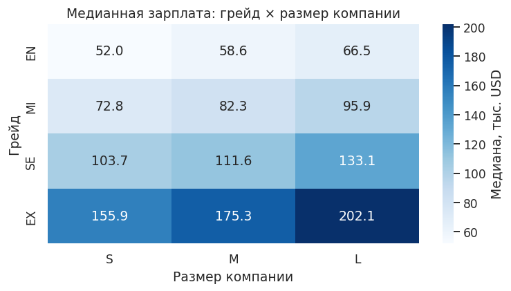

| experience_level | Разница медиан L к S, % |
| --- | --- |
| EN | 27.838 |
| MI | 31.818 |
| SE | 28.355 |
| EX | 29.678 |

```python
grade_size = feature_eda.pivot_table(
    index="experience_level", columns="company_size", values="salary_usd", aggfunc="median"
).reindex(index=LEVELS, columns=SIZES)
grade_size_n = pd.crosstab(feature_eda.experience_level, feature_eda.company_size).reindex(
    index=LEVELS, columns=SIZES
)
display(grade_size_n)
fig, ax = plt.subplots(figsize=(7, 4))
sns.heatmap(
    grade_size / 1000,
    annot=True,
    fmt=".1f",
    cmap="Blues",
    ax=ax,
    cbar_kws={"label": "Медиана, тыс. USD"},
)
ax.set(
    title="Медианная зарплата: грейд × размер компании",
    xlabel="Размер компании",
    ylabel="Грейд",
)
finish()
large_premium = grade_size["L"] / grade_size["S"] - 1
display((large_premium * 100).rename("Разница медиан L к S, %").to_frame())
```

Медианная зарплата в крупных компаниях выше, чем в малых, на 27,8–31,8% внутри каждого грейда. Это описательная разница. Отдельный совместный эффект грейда и размера компании здесь не проверялся.

Чтобы оценить пользу `senior_large`, нужно сравнить модели с этим признаком и без него на одинаковых разбиениях. Пока считать его улучшением рано.

### 5.4. Дополнительно: проверка PCA по лекции 4

Применим PCA к стажу, грейду, размеру компании, баллу соцпакета и длине описания. Грейд и размер кодируем порядковыми числами. Это условно задаёт расстояния между категориями, что важно помнить при интерпретации. Зарплата в PCA не участвует.

Заполнение медианой, стандартизация и PCA обучаются на train. Таблица и график каменистой осыпи помогут выбрать число компонент: по правилу Кайзера и порогу 95% сохранённой дисперсии. Нагрузки в отдельной таблице показывают корреляции признаков с компонентами. Дополнительно проверим, сколько информации о разбросе стажа и грейда сохраняет одна компонента.

**Цель.** Проверить идею сжатия коррелирующих признаков с помощью PCA. После заполнения пропусков и стандартизации на train рассчитываются доли сохранённой дисперсии и нагрузки. Отдельно исследуется одна компонента для пары «стаж и грейд».

|  | Собственное значение | Доля дисперсии | Накопленная доля |
| --- | --- | --- | --- |
| PC1 | 1.926 | 0.385 | 0.385 |
| PC2 | 1.018 | 0.204 | 0.589 |
| PC3 | 0.999 | 0.200 | 0.789 |
| PC4 | 0.983 | 0.197 | 0.985 |
| PC5 | 0.074 | 0.015 | 1.000 |

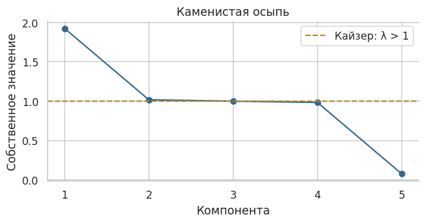

|  | PC1 | PC2 | PC3 | PC4 | PC5 |
| --- | --- | --- | --- | --- | --- |
| years_experience | 0.981 | 0.002 | -0.005 | 0.006 | 0.193 |
| exp_num | 0.981 | -0.002 | -0.005 | 0.005 | -0.193 |
| size_num | -0.003 | -0.636 | 0.447 | 0.629 | 0.000 |
| benefits_score | -0.012 | -0.337 | -0.894 | 0.295 | 0.000 |
| job_description_length | 0.008 | -0.707 | 0.025 | -0.707 | 0.001 |

```
Доля дисперсии пары стаж и грейд в одной компоненте, %: 96.27
```

```python
def pca_frame(frame):
    return frame.assign(
        exp_num=frame.experience_level.map(LEVEL_MAP),
        size_num=frame.company_size.map(SIZE_MAP),
    )


pca_columns = [
    "years_experience",
    "exp_num",
    "size_num",
    "benefits_score",
    "job_description_length",
]
pca_pipeline = Pipeline(
    [
        ("imputer", SimpleImputer(strategy="median")),
        ("scaler", StandardScaler()),
        ("pca", PCA(svd_solver="full")),
    ]
)
pca_train = pca_pipeline.fit_transform(pca_frame(train)[pca_columns])
pca_test = pca_pipeline.transform(pca_frame(test)[pca_columns])
pca = pca_pipeline.named_steps["pca"]
eigenvalues = pca.explained_variance_
variance = pca.explained_variance_ratio_
cumulative = np.cumsum(variance)
component_names = [f"PC{i + 1}" for i in range(len(pca_columns))]
n95 = int(np.searchsorted(cumulative, 0.95) + 1)
n_kaiser = int((eigenvalues > 1).sum())
display(
    pd.DataFrame(
        {
            "Собственное значение": eigenvalues,
            "Доля дисперсии": variance,
            "Накопленная доля": cumulative,
        },
        index=component_names,
    )
)
fig, ax = plt.subplots(figsize=(6.5, 3.5))
ax.plot(range(1, 6), eigenvalues, "o-", color=BLUE)
ax.axhline(1, color=GOLD, linestyle="--", label="Кайзер: λ > 1")
ax.set(
    xticks=range(1, 6),
    xlabel="Компонента",
    ylabel="Собственное значение",
    title="Каменистая осыпь",
)
ax.legend()
finish()
z_train = pca_pipeline.named_steps["scaler"].transform(
    pca_pipeline.named_steps["imputer"].transform(pca_frame(train)[pca_columns])
)
loadings = np.corrcoef(z_train.T, pca_train.T)[: len(pca_columns), len(pca_columns) :]
loading_table = pd.DataFrame(loadings, index=pca_columns, columns=component_names)
display(loading_table)
pair_pca = Pipeline(
    [("scaler", StandardScaler()), ("pca", PCA(n_components=1, svd_solver="full"))]
)
pair_train = pair_pca.fit_transform(pca_frame(train)[["years_experience", "exp_num"]])
pair_test = pair_pca.transform(pca_frame(test)[["years_experience", "exp_num"]])
pair_retained = pair_pca.named_steps["pca"].explained_variance_ratio_[0]
print("Доля дисперсии пары стаж и грейд в одной компоненте, %:", round(pair_retained * 100, 2))
```

Две компоненты сохраняют 58,86% дисперсии пяти признаков. Для порога 95% нужны четыре компоненты, правило Кайзера оставляет две. Одна компонента пары «стаж и грейд» сохраняет 96,27% её дисперсии.

Первая компонента в основном отражает опыт: стаж и грейд имеют большие нагрузки одного знака. Другие компоненты связаны с размером компании, соцпакетом и длиной описания. Некоторые собственные значения близки к 1, поэтому результат правила Кайзера может меняться от выборки к выборке.

Сжатие всех пяти признаков до двух теряет заметную часть разброса. Для будущей модели интереснее проверить одну компоненту стажа и грейда. В основную матрицу её пока не включаем.

Как сказано на слайде 30 лекции 4, «высокая вариативность ≠ высокая смысловая важность для конкретной исследовательской задачи». Поэтому сохранённая дисперсия не доказывает пользу для прогноза зарплаты. Красивое сжатие получилось, но место в итоговой модели ему ещё нужно заслужить.

### 5.5. Итоговые матрицы и проверки

Добавляем шесть новых признаков к исходным. Обучаем `ColumnTransformer` на обучающей части. Затем применяем его к отложенным данным и строкам без известной зарплаты. PCA в этот вариант не входит. Его можно будет сравнить с основной обработкой в отдельном эксперименте.

**Цель.** Собрать итоговые матрицы. Обработчик обучается на train и применяется к остальным строкам. Таблица проверок показывает сохранность CSV, учёт строк, разделение компаний и корректность матриц.

```python
final_preprocessor = make_preprocessor(base_numeric + new_columns, base_categorical)
X_train = final_preprocessor.fit_transform(train_fe)
X_test = final_preprocessor.transform(test_fe)
X_unknown_target = final_preprocessor.transform(create_features(unlabeled))
y_train = train.salary_usd.copy()
y_test = test.salary_usd.copy()

# Короткие проверки с понятными названиями.
matrices = [X_train, X_test, X_unknown_target]
selected_columns = base_numeric + new_columns + base_categorical
companies_overlap = train.company_name.isin(test.company_name).any()
jobs_overlap = train.job_id.isin(test.job_id).any()
train_target_unchanged = y_train.equals(raw.loc[train.index, "salary_usd"])
test_target_unchanged = y_test.equals(raw.loc[test.index, "salary_usd"])
csv_unchanged = source_sha256 == hashlib.sha256(DATA_PATH.read_bytes()).hexdigest()

checks = dict(data_checks)
checks.update(
    {
        "Рабочая копия создана из исходного CSV": source_matches,
        "Исходный CSV не изменён": csv_unchanged,
        "Все строки учтены": len(train) + len(test) + len(unlabeled) == len(raw),
        "Нет пересечений компаний": not companies_overlap,
        "Нет пересечений job_id": not jobs_overlap,
        "Матрицы без NaN и inf": all(np.isfinite(matrix).all() for matrix in matrices),
        "Одинаковое число столбцов": X_train.shape[1]
        == X_test.shape[1]
        == X_unknown_target.shape[1],
        "Зарплата и идентификаторы исключены": not any(
            column in selected_columns for column in ["salary_usd", "job_id", "company_name"]
        ),
        "Новые признаки не используют зарплату": features_ignore_salary,
        "Наблюдаемые зарплаты не заменены": train_target_unchanged and test_target_unchanged,
    }
)
check_results = pd.Series(checks, name="Проверка пройдена")
display(check_results.to_frame())
if not check_results.all():
    raise ValueError("Некоторые проверки не пройдены. См. таблицу выше.")

display(
    pd.DataFrame(
        {
            "Часть": ["Обучающая", "Отложенная", "Без известной зарплаты"],
            "Строки": [len(X_train), len(X_test), len(X_unknown_target)],
            "Признаки": [X_train.shape[1], X_test.shape[1], X_unknown_target.shape[1]],
        }
    )
)
```

|  | Проверка пройдена |
| --- | --- |
| Нет повторов job_id | True |
| Грейды есть в словаре | True |
| Размеры компаний есть в словаре | True |
| Формат работы имеет известный код | True |
| Уровни образования есть в словаре | True |
| Стаж находится между 0 и 60 годами | True |
| Дедлайн не раньше публикации | True |
| Рабочая копия создана из исходного CSV | True |
| Исходный CSV не изменён | True |
| Все строки учтены | True |
| Нет пересечений компаний | True |
| Нет пересечений job_id | True |
| Матрицы без NaN и inf | True |
| Одинаковое число столбцов | True |
| Зарплата и идентификаторы исключены | True |
| Новые признаки не используют зарплату | True |
| Наблюдаемые зарплаты не заменены | True |

|  | Часть | Строки | Признаки |
| --- | --- | --- | --- |
| 0 | Обучающая | 11195 | 111 |
| 1 | Отложенная | 3781 | 111 |
| 2 | Без известной зарплаты | 24 | 111 |

Подготовлены матрицы (11195, 111) (обучающая часть), (3781, 111) (отложенная часть) и (24, 111) (неизвестная цель); все проверки выполнены.

### Выводы по пунктам 4–5

Даты и категории приведены к единому виду, подозрительные значения обработаны по описанным правилам. Заполнение пропусков и масштабирование обучены только на train. Для двух числовых признаков сравнены MinMaxScaler, StandardScaler, RobustScaler, log1p и sqrt. Для категорий показаны порядковое кодирование и OHE. Строки без используемой зарплаты сохранены отдельно. Целевые значения не придумывались.

Созданы шесть признаков и проверена их связь с зарплатой с поправкой Холма. Расчёт не использует целевую переменную. Пользу для прогноза ещё предстоит проверить. `senior_large` объединяет уже связанные с зарплатой грейд и размер компании. Квадрат стажа меняет форму зависимости, сохраняя порядок наблюдений.

Стаж и грейд удалось сжать в одну компоненту. Для всех пяти признаков сжатие до двух компонент теряет заметную долю дисперсии. Поэтому PCA пока оставлен отдельным исследованием.

Проверена чувствительность к границам зарплаты, изменения записаны в журнал. Выводы относятся к этому учебному файлу. Причинные связи и улучшение прогноза здесь не проверялись.

### Источники методов

Для пунктов 4–5 использованы PDF лекций 1–4 из [папки курса](https://disk.360.yandex.ru/d/k903xBTIzxMmVQ): `Лекция1_Intro.pdf` (93 слайда), `Лекция2_EDA.pdf` (67), `Лекция3_FE.pdf` (49), `Лекция4_DR.pdf` (64). Номера основных слайдов приведены в начале пункта 4. Также использованы примеры масштабирования, корреляций и PCA из семинаров 2–4. Все видеозаписи лекций просмотрены нами. Материалы лекций также самостоятельно изучены на парах и после них.

Справочные материалы: [SciPy: Kendall τ](https://docs.scipy.org/doc/scipy/reference/generated/scipy.stats.kendalltau.html), [scikit-learn: StandardScaler](https://scikit-learn.org/stable/modules/generated/sklearn.preprocessing.StandardScaler.html), [scikit-learn: PCA](https://scikit-learn.org/stable/modules/generated/sklearn.decomposition.PCA.html), [поправка Холма](https://www.statsmodels.org/stable/generated/statsmodels.stats.multitest.multipletests.html).

### Использование генеративных моделей

Мы любим ИИ и часто им пользуемся, но к его ответам относимся осторожно. Для проверки результатов и редактирования использовали OpenAI Codex (GPT-6 Astra), Claude Opus 5 и Qimi K3. Мы лично разобрали и проверили весь код. При его подготовке использовали ИИ, а при выборе методов руководствовались лекциями. ИИ помог нам разобраться в библиотеке pandas и в работе с данными. Не скрываем, что большую часть кода разбирали и проверяли с помощью Codex и других моделей. Это помогало понять, как работает код, и находить простые ошибки. В Codex запускали расчёты и проверяли, соответствуют ли выводы таблицам и графикам. ИИ также помогал с подготовкой кода и черновых пояснений, в том числе в пунктах 4 и 5. В тексте есть наши формулировки и варианты, предложенные ИИ, которые затем редактировались. Исходные данные не генерировали.

Perplexity использовали для поиска справочной информации. Материалы лекций загрузили в NotebookLM для более простого усвоения, все материалы самостоятельно просмотрели как на парах, так и после них. Ответы моделей сопоставляли с лекциями и результатами расчётов.

**Примеры формулировок запросов:**

- «Покажи, как заполнить пропуски медианами обучающей выборки и применить те же значения к новым данным».
- «Сопоставь выводы с таблицами и графиками. Найди утверждения, которые не подтверждаются результатами».
- «Прочитай весь текст. Убери повторы и шаблонные обороты, сократи длинные предложения. Сохрани смысл и числа».
- «Проверь орфографию, пунктуацию и согласование слов. Не меняй условия задания».

Это примеры формулировок, а не дословный журнал переписки.

Мы надеемся, что проделанная работа вам понравится и вы оцените пасхалочки, которые мы оставили в этой работе 🙂